# Tugas Praktikum Metode Peramalan Deret Waktu Minggu 6 dan 7

G1401211066_Oktavia Galih Pratiwi

2023-10-16

## Packages

```r
library(ggplot2)
library(tsibble)
library(tseries)
library(MASS)
library(forecast)
library(TSA)
library(TTR)
library(aTSA)
library(graphics)
library(rio)
```

## Mengimpor data Europe Brent Spot Price FOB Dollars per Barrel

```r
databrentprice <- import("https://raw.githubusercontent.com/oktaviagalihpratiwi/praktikum-mpdwokta/main/Data/data_brentprice.csv")
databrentprice
```

```
##         Period  Price
## 1   01/01/2000  25.51
## 2   01/02/2000  27.78
## 3   01/03/2000  27.49
## 4   01/04/2000  22.76
## 5   01/05/2000  27.74
## 6   01/06/2000  29.80
## 7   01/07/2000  28.68
## 8   01/08/2000  30.20
## 9   01/09/2000  33.14
## 10  01/10/2000  30.96
## 11  01/11/2000  32.55
## 12  01/12/2000  25.66
## 13  01/01/2001  25.62
## 14  01/02/2001  27.50
```

[output cut: 269 more lines]

```r
stas <- ts(databrentprice$Price)
stas
```

```
## Time Series:
## Start = 1
## End = 283
## Frequency = 1
##   [1]  25.51  27.78  27.49  22.76  27.74  29.80  28.68  30.20  33.14  30.96
##  [11]  32.55  25.66  25.62  27.50  24.50  25.66  28.31  27.85  24.61  25.68
##  [21]  25.62  20.54  18.80  18.71  19.42  20.28  23.70  25.73  25.35  24.08
##  [31]  25.74  26.65  28.40  27.54  24.34  28.33  31.18  32.77  30.61  25.00
##  [41]  25.86  27.65  28.35  29.89  27.11  29.61  28.75  29.81  31.28  30.86
##  [51]  33.63  33.59  37.57  35.18  38.22  42.74  43.20  49.78  43.11  39.60
##  [61]  44.51  45.48  53.10  51.88  48.65  54.35  57.52  63.98  62.91  58.54
##  [71]  55.24  56.86  62.99  60.21  62.06  70.26  69.78  68.56  73.67  73.23
##  [81]  61.96  57.81  58.76  62.47  53.68  57.56  62.05  67.49  67.21  71.05
##  [91]  76.93  70.76  77.17  82.34  92.41  90.93  92.18  94.99 103.64 109.07
## [101] 122.80 132.32 132.72 113.24  97.23  71.58  52.45  39.95  43.44  43.32
```

[output cut: 18 more lines]

```r
str(stas)
```

```
##  Time-Series [1:283] from 1 to 283: 25.5 27.8 27.5 22.8 27.7 ...
```

## Eksplorasi Data

### Plot *Time Series* Data Penuh

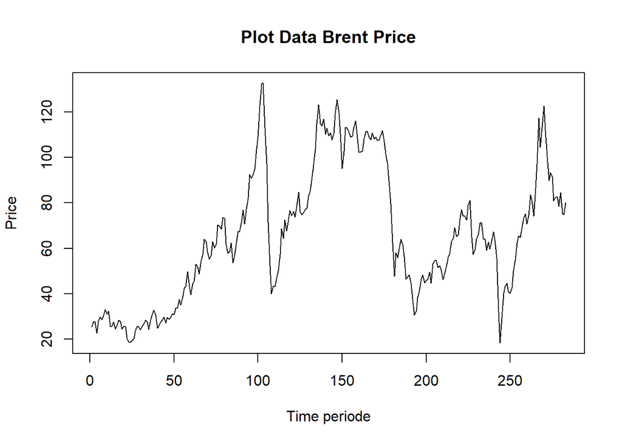

```r
plot.ts(stas, lty=1, xlab="Time periode", ylab="Price", main="Plot Data Brent Price")
```

Berdasarkan plot data deret waktu di atas, terlihat bahwa data cenderung memiliki trend naik turun yang menunjukkan data tidak stasioner dalam rataan dan ragam. Hal ini ditandai dengan data yang tidak bergerak pada nilai tengah tertentu dan adanya lebar pita pada plot yang cenderung berbeda. Berdasarkan pola data, pembagian data latih dan data uji ditetapkan dengan proporsi 72%:28%.

### Plot *Time Series* Data Latih

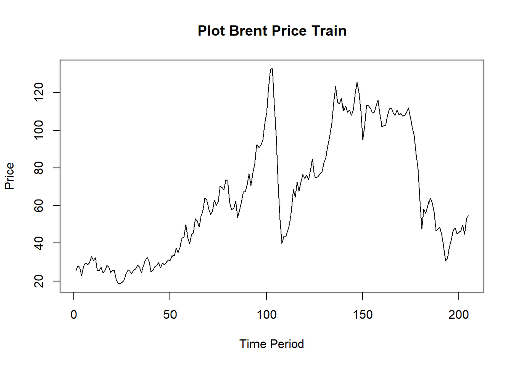

```r
pricetrain<-stas[1:205]
train.ts<-ts(pricetrain)
plot.ts(train.ts, lty=1, xlab="Time Period", ylab="Price", main="Plot Brent Price Train")
```

Berdasarkan plot data deret waktu pada data latih, terlihat bahwa data cenderung memiliki trend yang naik dan cenderung tidak bergerak pada nilai tengah tertentu. Hal ini mengindikasikan bahwa data tidak stasioner dalam rataan.

[figure not shown]

```r
pricetest<-stas[206:283]
test.ts<-ts(pricetest)
plot.ts(train.ts, lty=1, xlab="Time Period", ylab="Price", main="Plot Brent Price Test")
```

## Uji Stasioneritas Data

### Plot ACF

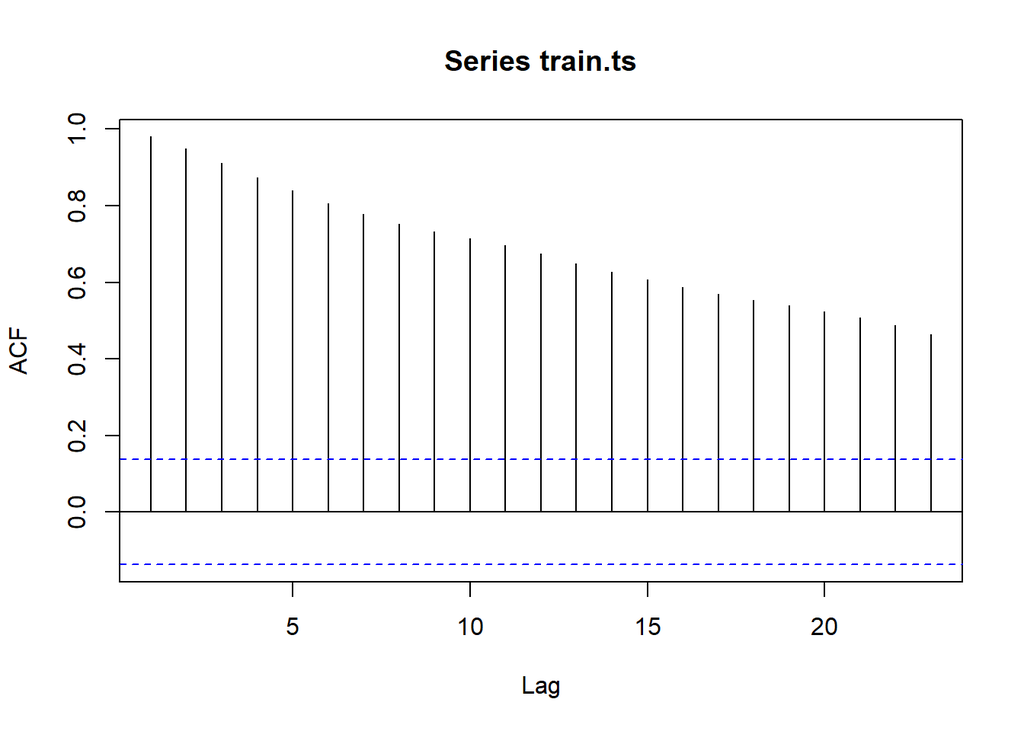

```r
acf(train.ts)
```

Berdasarkan plot ACF, terlihat bahwa plot ACF pada data tersebut menurun secara perlahan (*tails off slowly*) yang menandakan data tidak stasioner dalam rataan.

### Uji ADF

```r
tseries::adf.test(train.ts)
```

```
##
##  Augmented Dickey-Fuller Test
##
## data:  train.ts
## Dickey-Fuller = -1.8729, Lag order = 5, p-value = 0.6293
## alternative hypothesis: stationary
```

$H_0$ : Data tidak stasioner dalam rataan

$H_1$ : Data stasioner dalam rataan

Berdasarkan uji ADF tersebut, didapatkan *p-value* sebesar 0.6293 yang lebih besar dari taraf nyata 5% sehingga tidak tolak $H_0$ dan menandakan bahwa data tidak stasioner dalam rataan. Hal ini sesuai dengan hasil eksplorasi menggunakan plot time series dan plot ACF, sehingga perlu penanganan ketidakstasioneran model.

#### Plot Box-Cox

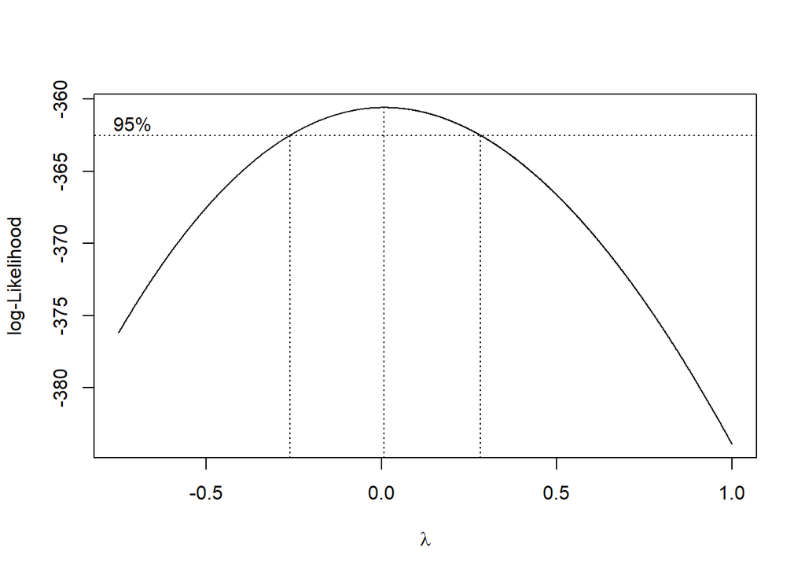

```r
n_train <- length(pricetrain)
index <- seq(1:n_train) #Banyaknya data latih
bc = boxcox(train.ts~index, lambda = seq(-0.75,1,by=0.001))
```

```r
#Nilai Rounded Lambda
lambda <- bc$x[which.max(bc$y)]
lambda
```

```
## [1] 0.007
```

```r
#SK
bc$x[bc$y > max(bc$y) - 1/2 * qchisq(.95,1)]
```

```
##   [1] -0.261 -0.260 -0.259 -0.258 -0.257 -0.256 -0.255 -0.254 -0.253 -0.252
##  [11] -0.251 -0.250 -0.249 -0.248 -0.247 -0.246 -0.245 -0.244 -0.243 -0.242
##  [21] -0.241 -0.240 -0.239 -0.238 -0.237 -0.236 -0.235 -0.234 -0.233 -0.232
##  [31] -0.231 -0.230 -0.229 -0.228 -0.227 -0.226 -0.225 -0.224 -0.223 -0.222
##  [41] -0.221 -0.220 -0.219 -0.218 -0.217 -0.216 -0.215 -0.214 -0.213 -0.212
##  [51] -0.211 -0.210 -0.209 -0.208 -0.207 -0.206 -0.205 -0.204 -0.203 -0.202
##  [61] -0.201 -0.200 -0.199 -0.198 -0.197 -0.196 -0.195 -0.194 -0.193 -0.192
##  [71] -0.191 -0.190 -0.189 -0.188 -0.187 -0.186 -0.185 -0.184 -0.183 -0.182
##  [81] -0.181 -0.180 -0.179 -0.178 -0.177 -0.176 -0.175 -0.174 -0.173 -0.172
##  [91] -0.171 -0.170 -0.169 -0.168 -0.167 -0.166 -0.165 -0.164 -0.163 -0.162
## [101] -0.161 -0.160 -0.159 -0.158 -0.157 -0.156 -0.155 -0.154 -0.153 -0.152
## [111] -0.151 -0.150 -0.149 -0.148 -0.147 -0.146 -0.145 -0.144 -0.143 -0.142
## [121] -0.141 -0.140 -0.139 -0.138 -0.137 -0.136 -0.135 -0.134 -0.133 -0.132
## [131] -0.131 -0.130 -0.129 -0.128 -0.127 -0.126 -0.125 -0.124 -0.123 -0.122
## [141] -0.121 -0.120 -0.119 -0.118 -0.117 -0.116 -0.115 -0.114 -0.113 -0.112
```

[output cut: 40 more lines]

Plot Boxcox menunjukkan nilai *rounded value* ($\lambda$) optimum sebesar **0.007** dan pada selang kepercayaan 95% nilai memiliki batas bawah **-0.261** dan batas atas **0.281**. Selang tersebut tidak memuat nilai satu sehingga dapat dikatakan bahwa data latih tidak stasioner dalam ragam.

### Penanganan Ketidakstasioneran Data

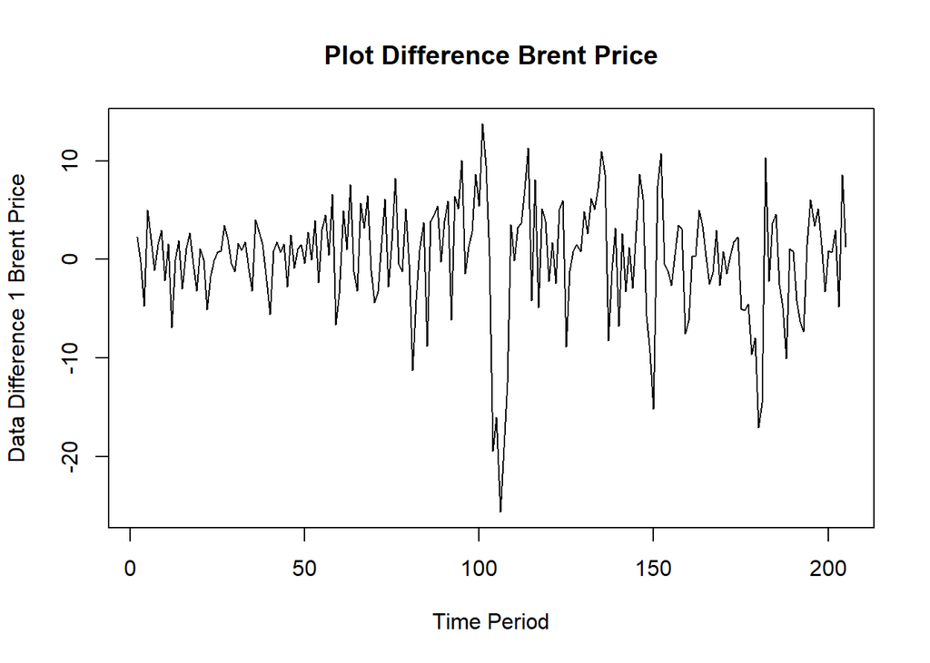

```r
train.diff<-diff(train.ts,differences = 1)
plot.ts(train.diff, lty=1, xlab="Time Period", ylab="Data Difference 1 Brent Price", main="Plot Difference Brent Price")
```

Berdasarkan plot data deret waktu, terlihat bahwa data sudah stasioner dalam rataan ditandai dengan data bergerak pada nilai tengah tertentu (tidak terdapat trend ataupun musiman pada data)

#### Plot ACF

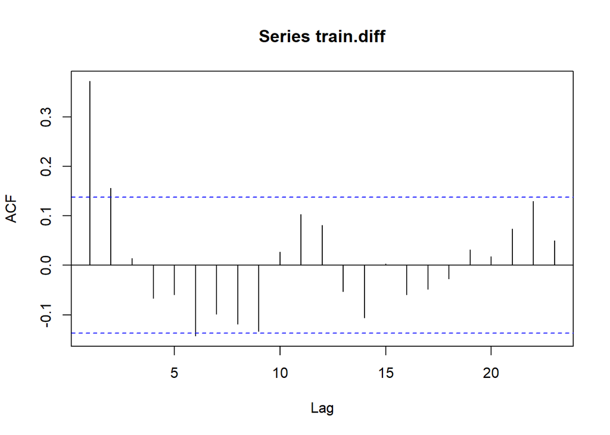

```r
acf(train.diff)
```

#### Uji ADF

```r
tseries::adf.test(train.diff)
```

```
##
##  Augmented Dickey-Fuller Test
##
## data:  train.diff
## Dickey-Fuller = -6.3557, Lag order = 5, p-value = 0.01
## alternative hypothesis: stationary
```

$H_0$ : Data tidak stasioner dalam rataan

$H_1$ : Data stasioner dalam rataan

Berdasarkan uji ADF tersebut, didapat *p-value* sebesar 0.01 yang lebih kecil dari taraf nyata 5% sehingga tolak $H_0$ atau data stasioner dalam rataan. Hal ini sesuai dengan hasil eksplorasi menggunakan plot time series dan plot ACF sehingga dalam hal ini ketidakstasioneran data sudah berhasil ditangani dan dapat dilanjutkan ke pemodelan

## Identifikasi Model

### Plot ACF

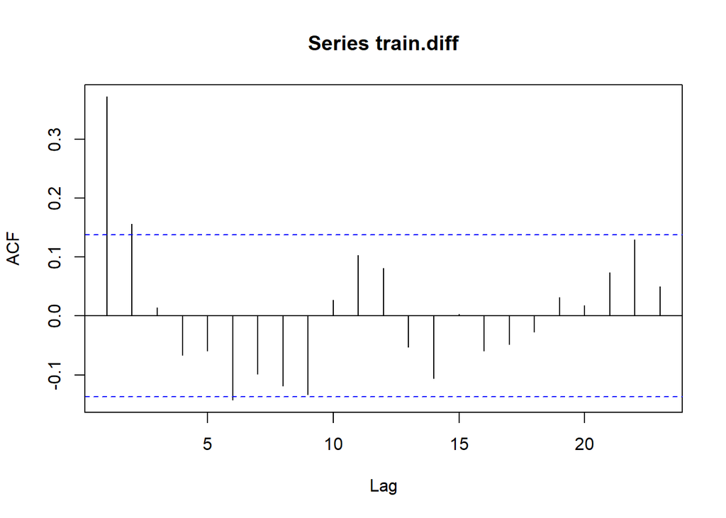

```r
acf(train.diff)
```

Berdasarkan plot tersebut, terlihat bahwa plot ACF cenderung *cuts off* pada lag ke 1, sehingga jika plot PACF dianggap *tails off*, maka model tentatifnya adalah ARIMA(0,1,1).

#### Plot PACF

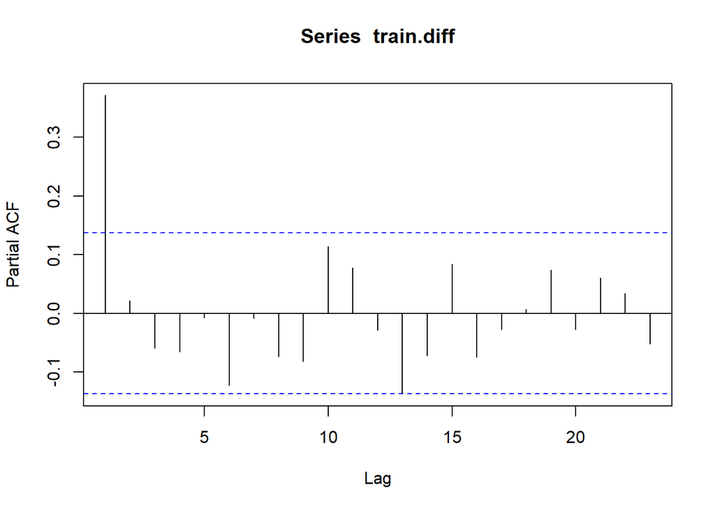

```r
pacf(train.diff)
```

Berdasarkan plot tersebut, terlihat bahwa plot PACF cenderung *cuts off* pada lag ke 1, sehingga jika plot ACF dianggap *tails off*, maka model tentatifnya adalah ARIMA(1,1,0).

Jika baik plot ACF maupun plot PACF keduanya dianggap tails of, maka model yang terbentuk adalah ARIMA(1,1,1).

#### Plot EACF

```r
eacf(train.diff)
```

```
## AR/MA
##   0 1 2 3 4 5 6 7 8 9 10 11 12 13
## 0 x x o o o x o o o o o  o  o  o
## 1 o o o o o o o o o o o  o  o  o
## 2 x o o o o o o o o o o  o  o  o
## 3 x x o o o o o o x o o  o  o  o
## 4 o x x o o o o o x o o  o  o  o
## 5 o x x x o o o o x o o  o  o  x
## 6 o x x x o o o o o o o  o  o  x
## 7 o x x x o o o o o o o  o  o  x
```

Identifikasi model menggunakan plot EACF dilakukan dengan melihat ujung segitiga pada pola segitiga nol. Dalam hal ini model tentatif yang terbentuk adalah ARIMA(0,1,2), ARIMA(0,1,3), ARIMA(2,1,1), ARIMA(3,1,2).

### Pendugaan Parameter Model Tentatif

#### ARIMA(0,1,1)

```r
model1.da=Arima(train.diff, order=c(0,1,1),method="ML")
summary(model1.da) #AIC=1299.19
```

```
## Series: train.diff
## ARIMA(0,1,1)
##
## Coefficients:
##           ma1
##       -0.6460
## s.e.   0.1318
##
## sigma^2 = 34.63:  log likelihood = -647.6
## AIC=1299.19   AICc=1299.25   BIC=1305.82
##
## Training set error measures:
##                      ME     RMSE      MAE      MPE     MAPE      MASE      ACF1
## Training set 0.01001589 5.855649 4.421347 74.20825 243.4286 0.8960818 0.1571705
```

```r
lmtest::coeftest(model1.da) #Seluruh parameter signifikan
```

```
##
## z test of coefficients:
##
##     Estimate Std. Error z value  Pr(>|z|)
## ma1 -0.64603    0.13180 -4.9018 9.497e-07 ***
## ---
## Signif. codes:  0 '***' 0.001 '**' 0.01 '*' 0.05 '.' 0.1 ' ' 1
```

#### ARIMA(1,1,0)

```r
model2.da=Arima(train.diff, order=c(1,1,0),method="ML")
summary(model2.da) #AIC=1314.82
```

```
## Series: train.diff
## ARIMA(1,1,0)
##
## Coefficients:
##           ar1
##       -0.3299
## s.e.   0.0663
##
## sigma^2 = 37.48:  log likelihood = -655.41
## AIC=1314.82   AICc=1314.88   BIC=1321.44
##
## Training set error measures:
##                       ME     RMSE      MAE     MPE     MAPE     MASE
## Training set 0.006017253 6.091732 4.560909 96.7346 305.8035 0.924367
##                     ACF1
## Training set -0.06091718
```

```r
lmtest::coeftest(model2.da) #Seluruh parameter signifikan
```

```
##
## z test of coefficients:
##
##      Estimate Std. Error z value  Pr(>|z|)
## ar1 -0.329936   0.066298 -4.9766 6.472e-07 ***
## ---
## Signif. codes:  0 '***' 0.001 '**' 0.01 '*' 0.05 '.' 0.1 ' ' 1
```

#### ARIMA(1,1,1)

```r
model3.da=Arima(train.diff, order=c(1,1,1),method="ML")
summary(model3.da) #AIC=1268.24
```

```
## Series: train.diff
## ARIMA(1,1,1)
##
## Coefficients:
##          ar1     ma1
##       0.3768  -1.000
## s.e.  0.0653   0.018
##
## sigma^2 = 29.01:  log likelihood = -631.12
## AIC=1268.24   AICc=1268.36   BIC=1278.18
##
## Training set error measures:
##                      ME     RMSE      MAE      MPE     MAPE      MASE
## Training set -0.1562432 5.346263 4.120044 103.7731 198.1846 0.8350162
##                     ACF1
## Training set -0.01305798
```

```r
lmtest::coeftest(model3.da) #Seluruh parameter signifikan
```

```
##
## z test of coefficients:
##
##      Estimate Std. Error  z value  Pr(>|z|)
## ar1  0.376751   0.065302   5.7694 7.957e-09 ***
## ma1 -1.000000   0.018026 -55.4739 < 2.2e-16 ***
## ---
## Signif. codes:  0 '***' 0.001 '**' 0.01 '*' 0.05 '.' 0.1 ' ' 1
```

#### ARIMA(0,1,2)

```r
model4.da=Arima(train.diff, order=c(0,1,2),method="ML")
summary(model4.da) #AIC=1273.32
```

```
## Series: train.diff
## ARIMA(0,1,2)
##
## Coefficients:
##           ma1      ma2
##       -0.6767  -0.3233
## s.e.   0.0659   0.0604
##
## sigma^2 = 29.7:  log likelihood = -633.66
## AIC=1273.32   AICc=1273.45   BIC=1283.26
##
## Training set error measures:
##                      ME    RMSE      MAE      MPE     MAPE      MASE       ACF1
## Training set -0.1820091 5.40919 4.098384 104.6727 183.9798 0.8306262 0.04461355
```

```r
lmtest::coeftest(model4.da) #Seluruh parameter signifikan
```

```
##
## z test of coefficients:
##
##      Estimate Std. Error  z value  Pr(>|z|)
## ma1 -0.676656   0.065912 -10.2660 < 2.2e-16 ***
## ma2 -0.323336   0.060431  -5.3505  8.77e-08 ***
## ---
## Signif. codes:  0 '***' 0.001 '**' 0.01 '*' 0.05 '.' 0.1 ' ' 1
```

#### ARIMA(0,1,3)

```r
model5.da=Arima(train.diff, order=c(0,1,3),method="ML")
summary(model5.da) #AIC=1269.9
```

```
## Series: train.diff
## ARIMA(0,1,3)
##
## Coefficients:
##           ma1      ma2      ma3
##       -0.6432  -0.1817  -0.1751
## s.e.   0.0707   0.0877   0.0727
##
## sigma^2 = 29.09:  log likelihood = -630.95
## AIC=1269.9   AICc=1270.1   BIC=1283.15
##
## Training set error measures:
##                      ME     RMSE      MAE      MPE     MAPE      MASE
## Training set -0.1683726 5.340596 4.123223 106.2512 193.4105 0.8356604
##                     ACF1
## Training set 0.004639127
```

```r
lmtest::coeftest(model5.da) #Seluruh parameter signifikan
```

```
##
## z test of coefficients:
##
##      Estimate Std. Error z value Pr(>|z|)
## ma1 -0.643249   0.070691 -9.0994  < 2e-16 ***
## ma2 -0.181696   0.087694 -2.0719  0.03827 *
## ma3 -0.175055   0.072715 -2.4074  0.01607 *
## ---
## Signif. codes:  0 '***' 0.001 '**' 0.01 '*' 0.05 '.' 0.1 ' ' 1
```

#### ARIMA(2,1,1)

```r
model6.da=Arima(train.diff, order=c(2,1,1),method="ML")
summary(model6.da) #AIC=1270.09
```

```
## Series: train.diff
## ARIMA(2,1,1)
##
## Coefficients:
##          ar1     ar2      ma1
##       0.3670  0.0266  -1.0000
## s.e.  0.0702  0.0704   0.0174
##
## sigma^2 = 29.14:  log likelihood = -631.05
## AIC=1270.09   AICc=1270.3   BIC=1283.35
##
## Training set error measures:
##                      ME     RMSE      MAE      MPE     MAPE      MASE
## Training set -0.1517902 5.345079 4.124248 102.7743 195.9212 0.8358683
##                      ACF1
## Training set -0.001607393
```

```r
lmtest::coeftest(model6.da) #AR2 tidak signifikan
```

```
##
## z test of coefficients:
##
##      Estimate Std. Error  z value Pr(>|z|)
## ar1  0.367024   0.070184   5.2295  1.7e-07 ***
## ar2  0.026552   0.070436   0.3770   0.7062
## ma1 -1.000000   0.017388 -57.5125  < 2e-16 ***
## ---
## Signif. codes:  0 '***' 0.001 '**' 0.01 '*' 0.05 '.' 0.1 ' ' 1
```

#### ARIMA(3,1,2)

```r
model7.da=Arima(train.diff, order=c(3,1,2),method="ML")
summary(model7.da) #AIC=1271.48
```

```
## Series: train.diff
## ARIMA(3,1,2)
##
## Coefficients:
##          ar1      ar2      ar3      ma1     ma2
##       1.1671  -0.2423  -0.0886  -1.8088  0.8100
## s.e.  0.3210   0.1699   0.0816   0.3370  0.3319
##
## sigma^2 = 29.09:  log likelihood = -629.74
## AIC=1271.48   AICc=1271.9   BIC=1291.35
##
## Training set error measures:
##                      ME     RMSE      MAE      MPE     MAPE      MASE
## Training set -0.2099481 5.314036 4.117077 110.4981 204.4255 0.8344149
##                      ACF1
## Training set -0.003746152
```

```r
lmtest::coeftest(model7.da) #AR2 dan AR3 tidak signifikan
```

```
##
## z test of coefficients:
##
##      Estimate Std. Error z value  Pr(>|z|)
## ar1  1.167144   0.320974  3.6363 0.0002766 ***
## ar2 -0.242322   0.169915 -1.4261 0.1538272
## ar3 -0.088587   0.081627 -1.0853 0.2778054
## ma1 -1.808817   0.336956 -5.3681 7.956e-08 ***
## ma2  0.810016   0.331891  2.4406 0.0146625 *
## ---
## Signif. codes:  0 '***' 0.001 '**' 0.01 '*' 0.05 '.' 0.1 ' ' 1
```

```r
# Membuat vektor yang berisi nama model
model_names <- c("model1.da", "model2.da", "model3.da", "model4.da", "model5.da", "model6.da", "model7.da")

get_aic <- function(model) {
  return(AIC(model))
}

result <- data.frame()

for (i in model_names) {
  model <- get(i)
    aic <- get_aic(model)
    result <- rbind(result, aic)
}
colnames(result) <- "AIC"
rownames(result) <- model_names
result
```

```
##                AIC
## model1.da 1299.194
## model2.da 1314.816
## model3.da 1268.236
## model4.da 1273.324
## model5.da 1269.902
## model6.da 1270.093
## model7.da 1271.475
```

### Analisis Sisaan

Model terbaik hasil identifikasi kemudian dicek asumsi sisaannya. Sisaan model ARIMA harus memenuhi asumsi normalitas, kebebasan sisaan, dan kehomogenan ragam. Diagnostik model dilakukan secara eksplorasi dan uji formal.

#### Eksplorasi Sisaan

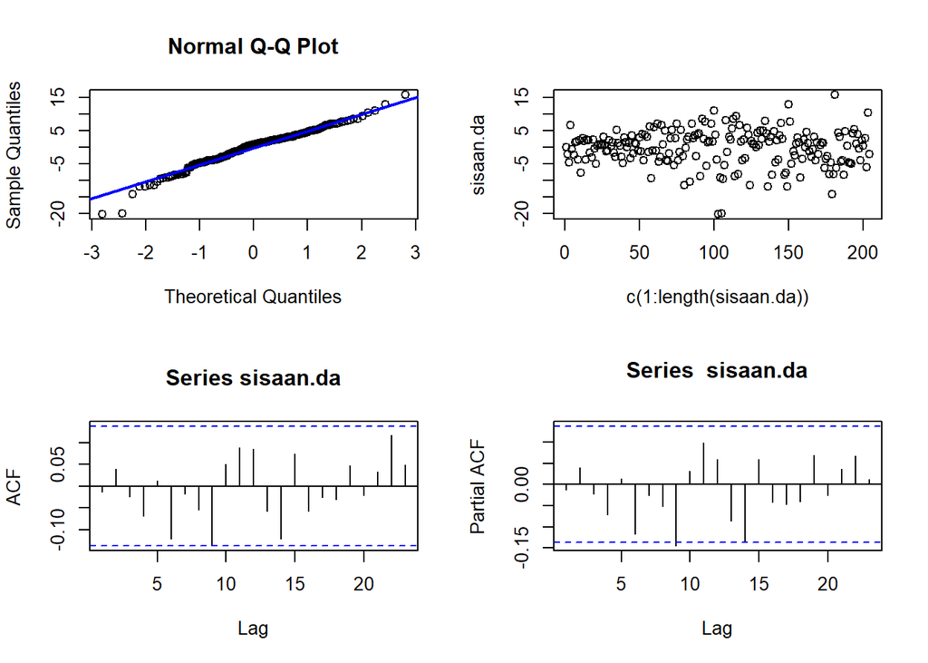

```r
#Eksplorasi
sisaan.da <- model3.da$residuals
par(mfrow=c(2,2))
qqnorm(sisaan.da)
qqline(sisaan.da, col = "blue", lwd = 2)
plot(c(1:length(sisaan.da)),sisaan.da)
acf(sisaan.da)
pacf(sisaan.da)
```

```r
par(mfrow = c(1,1))
```

#### Uji Formal

```r
#1) Sisaan Menyebar Normal
ks.test(sisaan.da,"pnorm")  #Tolak H0, maka sisaan tidak menyebar normal
```

```
##
##  Asymptotic one-sample Kolmogorov-Smirnov test
##
## data:  sisaan.da
## D = 0.35286, p-value < 2.2e-16
## alternative hypothesis: two-sided
```

Selain dengan eksplorasi, asumsi tersebut dapat diuji menggunakan uji formal. Pada tahapan ini uji formal yang digunakan untuk normalitas adalah uji Kolmogorov-Smirnov (KS). Hipotesis pada uji KS adalah sebagai berikut.

$H_0$ : Sisaan menyebar normal

$H_1$ : Sisaan tidak menyebar normal

```r
#2) Sisaan saling bebas/tidak ada autokorelasi
Box.test(sisaan.da, type = "Ljung")  #Tidak tolak H0, maka ragam sisaan saling bebas
```

```
##
##  Box-Ljung test
##
## data:  sisaan.da
## X-squared = 0.035298, df = 1, p-value = 0.851
```

Selanjutnya akan dilakukan uji formal untuk kebebasan sisaan menggunakan uji Ljung-Box. Hipotesis yang digunakan adalah sebagai berikut.

$H_0$ : Sisaan saling bebas

$H_1$ : Sisaan tidak tidak saling bebas

Berdasarkan uji Ljung-Box tersebut, didapat *p-value* sebesar 0.851 yang lebih besar dari taraf nyata 5% sehingga tidak tolak $H_0$ dan menandakan bahwa sisaan saling bebas. Hal ini sesuai dengan eksplorasi.

```r
#3) Sisaan homogen
Box.test((sisaan.da)^2, type = "Ljung") #Tolak H0, maka ragam sisaan tidak homogen
```

```
##
##  Box-Ljung test
##
## data:  (sisaan.da)^2
## X-squared = 9.7517, df = 1, p-value = 0.001792
```

Hipotesis yang digunakan untuk uji kehomogenan ragam adalah sebagai berikut.

$H_0$ : Ragam sisaan homogen

$H_1$ : Ragam sisaan tidak homogen

Berdasarkan uji Ljung-Box terhadap sisaan kuadrat tersebut, didapat *p-value* sebesar 0.001792 yang kurang dari taraf nyata 5% sehingga tolak $H_0$ dan menandakan bahwa ragam sisaan tidak homogen. Hal ini sesuai dengan eksplorasi.

```r
#4) Nilai tengah sisaan sama dengan nol
t.test(sisaan.da, mu = 0, conf.level = 0.95)  #Tidak tolak H0, maka nilai tengah sisaan sama dengan 0
```

```
##
##  One Sample t-test
##
## data:  sisaan.da
## t = -0.41657, df = 203, p-value = 0.6774
## alternative hypothesis: true mean is not equal to 0
## 95 percent confidence interval:
##  -0.8957834  0.5832969
## sample estimates:
##  mean of x
## -0.1562432
```

Terakhir, dengan uji-t, akan dicek apakah nilai tengah sisaan sama dengan nol. Hipotesis yang diujikan sebagai berikut.

$H_0$ : Nilai tengah sisaan sama dengan 0

$H_1$ : Nilai tengah sisaan tidak sama dengan 0

Berdasarkan uji tersebut, didapat *p-value* sebesar 0.6774 yang lebih besar dari taraf nyata 5% sehingga tidak tolak $H_0$ dan menandakan bahwa nilai tengah sisaan sama dengan nol.Hal ini sesuai dengan eksplorasi.

## Overfitting

```r
model3a.da=Arima(train.diff, order=c(2,1,1),method="ML")
summary(model3a.da) #AIC=1270.09
```

```
## Series: train.diff
## ARIMA(2,1,1)
##
## Coefficients:
##          ar1     ar2      ma1
##       0.3670  0.0266  -1.0000
## s.e.  0.0702  0.0704   0.0174
##
## sigma^2 = 29.14:  log likelihood = -631.05
## AIC=1270.09   AICc=1270.3   BIC=1283.35
##
## Training set error measures:
##                      ME     RMSE      MAE      MPE     MAPE      MASE
## Training set -0.1517902 5.345079 4.124248 102.7743 195.9212 0.8358683
##                      ACF1
## Training set -0.001607393
```

```r
lmtest::coeftest(model3a.da) #AR2 tidak sginifikan
```

```
##
## z test of coefficients:
##
##      Estimate Std. Error  z value Pr(>|z|)
## ar1  0.367024   0.070184   5.2295  1.7e-07 ***
## ar2  0.026552   0.070436   0.3770   0.7062
## ma1 -1.000000   0.017388 -57.5125  < 2e-16 ***
## ---
## Signif. codes:  0 '***' 0.001 '**' 0.01 '*' 0.05 '.' 0.1 ' ' 1
```

```r
model3b.da=Arima(train.diff, order=c(1,1,2),method="ML")
summary(model3b.da) #AIC=1270.13
```

```
## Series: train.diff
## ARIMA(1,1,2)
##
## Coefficients:
##          ar1      ma1     ma2
##       0.4222  -1.0526  0.0526
## s.e.  0.1495   0.1610  0.1600
##
## sigma^2 = 29.14:  log likelihood = -631.06
## AIC=1270.13   AICc=1270.33   BIC=1283.38
##
## Training set error measures:
##                      ME    RMSE      MAE      MPE     MAPE     MASE
## Training set -0.1526617 5.34539 4.123058 102.9604 196.4415 0.835627
##                      ACF1
## Training set -0.004540973
```

```r
lmtest::coeftest(model3b.da) #MA2 tidak signifikan
```

```
##
## z test of coefficients:
##
##      Estimate Std. Error z value  Pr(>|z|)
## ar1  0.422180   0.149547  2.8231  0.004757 **
## ma1 -1.052587   0.160982 -6.5385 6.212e-11 ***
## ma2  0.052587   0.160029  0.3286  0.742451
## ---
## Signif. codes:  0 '***' 0.001 '**' 0.01 '*' 0.05 '.' 0.1 ' ' 1
```

Model hasil overfitting terdapat parameter yang tidak signifikan, sehingga model terbaiknya adalah ARIMA(1,1,1).

## Peramalan

```r
#---FORECAST---#
ramalan.da <- forecast::forecast(model3.da, h = 78)
ramalan.da
```

```
##     Point Forecast     Lo 80    Hi 80     Lo 95    Hi 95
## 206      0.5732627 -6.345987 7.492512 -10.00882 11.15534
## 207      0.3107662 -7.095079 7.716611 -11.01550 11.63703
## 208      0.2118704 -7.264884 7.688625 -11.22284 11.64658
## 209      0.1746114 -7.313812 7.663034 -11.27794 11.62717
## 210      0.1605740 -7.330128 7.651276 -11.29547 11.61661
## 211      0.1552854 -7.335976 7.646546 -11.30161 11.61218
## 212      0.1532929 -7.338136 7.644722 -11.30386 11.61044
## 213      0.1525422 -7.338944 7.644028 -11.30470 11.60978
## 214      0.1522594 -7.339248 7.643766 -11.30501 11.60953
## 215      0.1521528 -7.339362 7.643667 -11.30513 11.60944
## 216      0.1521127 -7.339405 7.643630 -11.30517 11.60940
## 217      0.1520976 -7.339421 7.643616 -11.30519 11.60939
## 218      0.1520919 -7.339427 7.643611 -11.30520 11.60938
## 219      0.1520897 -7.339429 7.643609 -11.30520 11.60938
```

[output cut: 64 more lines]

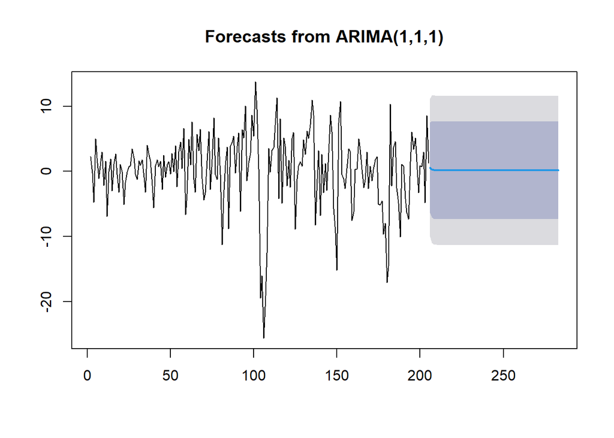

```r
data.ramalan.da <- ramalan.da$mean
plot(ramalan.da)
```

Berdasarkan hasil plot ramalan di atas, dapat dilihat bahwa ramalan ARIMA(1,1,1) cenderung stabil hingga akhir periode. Selanjutnya, dapat dicari nilai akurasi antara hasil ramalan dengan data uji sebagai berikut.

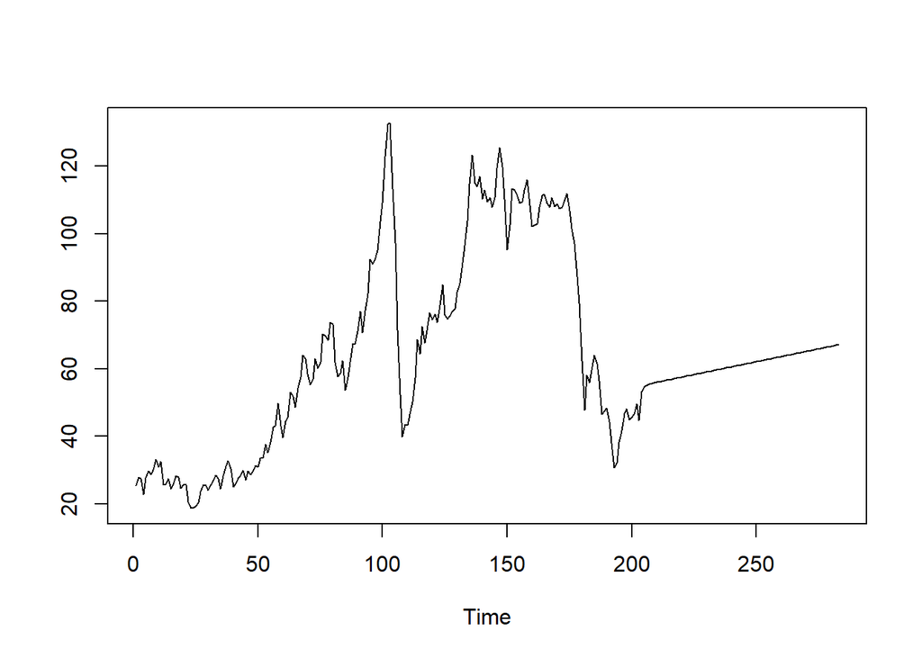

```r
pt_1 <- train.ts[205] #Nilai akhir data latih
hasil.forc.Diff <- data.ramalan.da
hasil <- diffinv(hasil.forc.Diff, differences = 1) + pt_1
#has.1 sama hasilnta dengan: cumsum(c(pt_1,hasil.forc.Diff))
ts.plot(train.ts,hasil)
```

```r
perbandingan.da<-matrix(data=c(head(test.ts, n=78), hasil[-1]),
                     nrow = 78, ncol = 2)
colnames(perbandingan.da)<-c("Aktual","Hasil Forecast")
perbandingan.da
```

```
##       Aktual Hasil Forecast
##  [1,]  54.87       55.15326
##  [2,]  51.59       55.46403
##  [3,]  52.31       55.67590
##  [4,]  50.33       55.85051
##  [5,]  46.37       56.01108
##  [6,]  48.48       56.16637
##  [7,]  51.70       56.31966
##  [8,]  56.15       56.47221
##  [9,]  57.51       56.62446
## [10,]  62.71       56.77662
## [11,]  64.37       56.92873
## [12,]  69.08       57.08083
## [13,]  65.32       57.23292
## [14,]  66.02       57.38501
```

[output cut: 64 more lines]

```r
accuracy(ts(hasil[-1]), head(test.ts, n=78))
```

```
##                ME     RMSE      MAE     MPE     MAPE      ACF1 Theil's U
## Test set 7.185178 19.40349 14.54504 1.72627 23.34562 0.9223205  2.673837
```

Nilai MAPE lebih besar dari 10% maka model ARIMA (1,1,1) kurang baik untuk digunakan dalam peramalan.